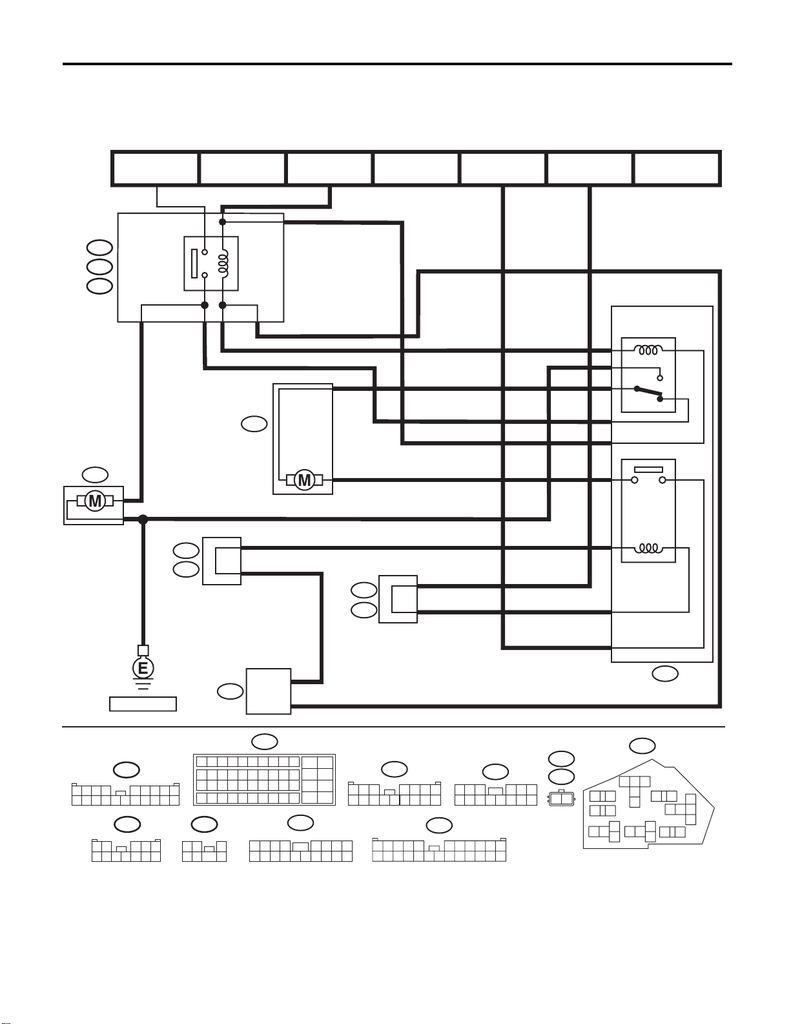

CO(w/o STI)-7

Radiator Fan System

COOLING

2. Radiator Fan System

A: WIRING DIAGRAM

Radiator fan system <Ref. to WI-340, WIRING DIAGRAM, Radiator Fan System.>

A:

0111

567

F109

B:

34 567

10 11 12 13 14 15 16 17

21

9

8

18

F108

A:

123 456

789

10 11 12 13 14

B361

D:

123

4567

89

B360

C:

24

23

25

12 13 14

15

16

26

2221

20

19

1817

10 11

2

4

5

13

F27

F16

F17

12

B19

C11

E6

E5

C10

B7

B360

C:

F109

B:

B361

D:

F108

A:

B134

A:

71

91

81

61

41

21

31

51

C1

B10

A16

D7

F17

2

1

1

2

F16

A25

A37

F27

CO-03382

B:

312

745 6

12 345

6789

011121

1234 56789

B143

F35 F36

F36E:

F35C:

B143B:

10

11 12

23 24

35 36

47 48

3

5

6

12

45

21

33

B134

ECM

MAIN

FUSE BOX

(M/B)

THROUGH JOINT

CONNECTOR

MB-11

F/B FUSE NO. 26

(IG)

MB-4

M/B FUSE NO. 3

(B)

FB-46

F/B FUSE NO. 22

(IG)

RELAY HOLDER

THROUGH JOINT

CONNECTOR

SUB FAN RELAY

MAIN FAN

RELAY 2

SUB FAN

MOTOR

MAIN FAN

MOTOR

REF. TO GND

MAIN FAN

RELAY 1

MB-4

M/B FUSE NO. 2

(B)

RELAY HOLDER

[figure not shown]

CO(w/o STI)-8

Radiator Fan System

COOLING

B: INSPECTION

Operating condition:

*1

Including the condition under which vehicle is stopped (0 km/h (0 MPH)).

*2

The fan may run at High-Speed when ambient temperature is high.

Vehicle speed

A/C compres-

sor load

Engine coolant temperature

Increase:

94°C (201°F) or less

Decrease:

92°C (198°F) or less

Increase:

95 — 99°C (203 — 210°F)

Decrease:

93 — 94°C (199 — 201°F)

Increase:

100°C (212°F) or more

Decrease:

95°C (203°F) or more

Radiator fan operation Radiator fan operation Radiator fan operation

During acceleration:

19 km/h (12 MPH)

or less

*1

During deceleration:

10 km/h (6 MPH)

or less

*1

OFF OFF Low-Speed High-Speed

Low Low-Speed Low-Speed High-Speed

High High-Speed High-Speed High-Speed

During acceleration:

20 — 69 km/h

(12 — 43 MPH)

During deceleration:

11 — 64 km/h

(7 — 40 MPH)

OFF OFF Low-Speed High-Speed

Low High-Speed High-Speed High-Speed

High High-Speed High-Speed High-Speed

During acceleration:

70 — 134 km/h

(43 — 83 MPH)

During deceleration:

65 — 129 km/h

(40 — 80 MPH)

OFF OFF Low-Speed High-Speed

Low OFF

*2

Low-Speed

*2

High-Speed

High Low-Speed

*2

High-Speed High-Speed

During acceleration:

135 km/h (84 MPH)

or more

During deceleration:

130 km/h (81 MPH)

or more

OFF OFF OFF High-Speed

Low OFF Low-Speed High-Speed

High OFF Low-Speed High-Speed

[figure not shown]

CO(w/o STI)-9

Radiator Fan System

COOLING

DIAGNOSIS:

Radiator main fan and radiator sub fan do not rotate under the above operating conditions.

Step Check Yes No

1 CHECK OPERATION OF RADIATOR FAN.

1) Install the delivery mode fuse.

2) Turn the ignition switch to ON.

3) Using the Subaru Select Monitor, perform

the compulsory operation check for the radiator

fan relay.

NOTE:

• When performing the compulsory operation

check for the radiator fan relay using the Subaru

Select Monitor, the radiator main fan and radia-

tor sub fan will repeat low speed revolution →

high speed revolution → OFF in this order.

• Subaru Select Monitor

For detailed operation procedures, refer to “PC

application help for Subaru Select Monitor”.

Do the radiator main fans and

radiator sub fans rotate at low

speed?

Go to step 2. Go to step 3.

2 CHECK OPERATION OF RADIATOR FAN.

1) Install the delivery mode fuse.

2) Turn the ignition switch to ON.

3) Using the Subaru Select Monitor, perform

the compulsory operation check for the radiator

fan relay.

NOTE:

• When performing the compulsory operation

check for the radiator fan relay using the Subaru

Select Monitor, the radiator main fan and radia-

tor sub fan will repeat low speed revolution →

high speed revolution → OFF in this order.

• Subaru Select Monitor

For detailed operation procedures, refer to “PC

application help for Subaru Select Monitor”.

Do the radiator main fans and

radiator sub fans rotate at high

speed?

Radiator main fan

system is normal.

Go to step 27.

3 CHECK POWER SUPPLY TO SUB FAN RE-

LAY.

1) Turn the ignition switch to OFF.

2) Remove the sub fan relay from the relay

holder.

3) Measure the voltage between the sub fan

relay terminal and chassis ground.

Connector & terminal

(F27) No. 17 (+) — Chassis ground (–):

Is the voltage 10 V or more? Go to step 4. Go to step 5.

4 CHECK POWER SUPPLY TO SUB FAN RE-

LAY.

1) Turn the ignition switch to ON.

2) Measure the voltage between the sub fan

relay terminal and chassis ground.

Connector & terminal

(F27) No. 20 (+) — Chassis ground (–):

Is the voltage 10 V or more? Go to step 7. Go to step 6.

5 CHECK FUSE.

1) Turn the ignition switch to OFF.

2) Remove the fuse No. 3.

3) Check the condition of fuse.

Is the fuse blown out? Replace the fuse. Repair the power

supply line.

6 CHECK FUSE.

1) Turn the ignition switch to OFF.

2) Remove the fuse No. 22.

3) Check the condition of fuse.

Is the fuse blown out? Replace the fuse. Repair the power

supply line.

[figure not shown]

CO(w/o STI)-10

Radiator Fan System

COOLING

7 CHECK SUB FAN RELAY.

1) Turn the ignition switch to OFF.

2) Measure the resistance between sub fan

relay terminals.

Terminals

No. 17 — No. 18:

Is the resistance 1 MΩ or

more?

Go to step 8. Replace the sub

fan relay. <Ref. to

AC-32, Relay and

Fuse.>

8 CHECK SUB FAN RELAY.

1) Connect the battery to terminals No. 19 and

No. 20 of the sub fan relay.

2) Measure the resistance between sub fan

relay terminals.

Terminals

No. 17 — No. 18:

Is the resistance less than 1 Ω? Go to step 9. Replace the sub

fan relay. <Ref. to

AC-32, Relay and

Fuse.>

9 CHECK HARNESS BETWEEN SUB FAN RE-

LAY TERMINAL AND SUB FAN MOTOR

CONNECTOR.

1) Disconnect the connector from the sub fan

motor.

2) Measure the resistance of harness between

the sub fan relay terminal and sub fan motor

connector.

Connector & terminal

(F16) No. 1 — (F27) No. 18:

Is the resistance less than 1 Ω? Go to step 10. Repair the open

circuit of harness

between sub fan

relay terminal and

sub fan motor con-

nector.

10 CHECK HARNESS BETWEEN SUB FAN MO-

TOR CONNECTOR AND MAIN FAN RELAY 2

CONNECTOR.

1) Remove main fan relay 2 from the relay

holder.

2) Measure the resistance of harness between

sub fan motor connector and main fan relay 2

connector.

Connector & terminal

(F16) No. 2 — (F27) No. 12:

Is the resistance less than 1 Ω? Go to step 11. Repair the open

circuit of the har-

ness between sub

fan motor connec-

tor and main fan

relay 2 connector.

11 CHECK FOR POOR CONTACT.

Check poor contact of sub fan motor connector.

Is there poor contact of the sub

fan motor connector?

Repair the poor

contact of sub fan

motor connector.

Go to step 12.

12 CHECK SUB FAN MOTOR.

Connect the battery positive (+) terminal to ter-

minal No. 1 of the sub fan motor, and the ground

(–) terminal to terminal No. 2.

Does the radiator sub fan

rotate?

Go to step 13. Replace the sub

fan motor. <Ref. to

CO(w/o STI)-49,

Radiator Sub Fan

and Fan Motor.>

13 CHECK MAIN FAN RELAY 2.

Measure the resistance of main fan relay 2.

Terminals

No. 14 — No. 12:

Is the resistance less than 1 Ω? Go to step 14. Replace the main

fan relay 2. <Ref. to

AC-32, Relay and

Fuse.>

14 CHECK HARNESS BETWEEN MAIN FAN

RELAY 2 AND MAIN FAN MOTOR CONNEC-

TOR.

1) Disconnect the connector from the main fan

motor.

2) Measure the resistance of the harness

between main fan relay 2 terminal and main fan

motor connector.

Connector & terminal

(F17) No. 1 — (F27) No. 14:

Is the resistance less than 1 Ω? Go to step 15. Repair the open

circuit of the har-

ness between

main fan relay 2

terminal and main

fan motor connec-

tor.

Step Check Yes No

[figure not shown]

CO(w/o STI)-11

Radiator Fan System

COOLING

15 CHECK GROUND CIRCUIT OF MAIN FAN

MOTOR.

Measure the resistance between main fan

motor connector and chassis ground.

Connector & terminal

(F17) No. 2 — Chassis ground:

Is the resistance less than 5 Ω? Go to step 16. Repair the open

circuit of the har-

ness between

main fan motor

connector and

chassis ground.

16 CHECK FOR POOR CONTACT.

Check poor contact of main fan motor connec-

tor.

Is there poor contact of the

main fan motor connector?

Repair the poor

contact of main fan

motor connector.

Go to step 17.

17 CHECK MAIN FAN MOTOR.

Connect the battery positive (+) terminal to ter-

minal No. 1 of the main fan motor, and the

ground (–) terminal to terminal No. 2.

Does the radiator main fan

rotate?

Go to step 18. Replace the main

fan motor. <Ref. to

CO(w/o STI)-46,

Radiator Main Fan

and Fan Motor.>

18 CHECK HARNESS BETWEEN SUB FAN RE-

LAY AND ECM.

1) Disconnect the connector from ECM.

2) Measure the resistance between the sub

fan relay terminal and ECM connector.

Connector & terminal

(B134) No. 25 — (F27) No. 19:

Is the resistance less than 1 Ω? Go to step 19. Repair the open

circuit of harness

between sub fan

relay terminal and

ECM.

19 CHECK FOR POOR CONTACT.

Check for poor contact of ECM connector.

Is there poor contact of ECM

connector?

Repair the poor

contact of ECM

connector.

Check the DTC.

Repair the trouble

cause. <Ref. to

EN(w/o STI)(diag)-

46, Read Diagnos-

tic Trouble Code

(DTC).>

20 CHECK MAIN FAN RELAY 1.

1) Turn the ignition switch to OFF.

2) Remove main fan relay 1 from the main fuse

box.

3) Measure the resistance between terminals

of main fan relay 1 switch.

Is the resistance 1 MΩ or

more?

Go to step 21. Replace the main

fan relay 1. <Ref. to

AC-32, Relay and

Fuse.>

21 CHECK MAIN FAN RELAY 1.

1) Connect the main fan relay 1 coil side termi-

nal to the battery.

2) Measure the resistance between terminals

of main fan relay 1 switch.

Is the resistance less than 1 Ω? Go to step 22. Replace the main

fan relay 1. <Ref. to

AC-32, Relay and

Fuse.>

22 CHECK HARNESS BETWEEN MAIN FAN

RELAY 1 AND MAIN FAN MOTOR CONNEC-

TOR.

1) Disconnect the connector from the main fan

motor.

2) Measure the resistance of the harness

between main fan relay 1 terminal and main fan

motor connector.

Connector & terminal

(F17) No. 1 — (F36) No. 6:

Is the resistance less than 1

Ω? Go to step 23. Repair the open

circuit of the har-

ness between

main fan relay 1

terminal and main

fan motor connec-

tor.

23 CHECK HARNESS BETWEEN MAIN FAN

RELAY 1 AND ECM.

1) Disconnect the connector from ECM.

2) Measure the resistance between main fan

relay 1 terminal and ECM connector.

Connector & terminal

(B134) No. 37 — (B143) No. 7:

Is the resistance less than 1 Ω? Go to step 24. Repair the open

circuit of the har-

ness between

main fan relay 1

terminal and ECM.

Step Check Yes No

[figure not shown]

CO(w/o STI)-12

Radiator Fan System

COOLING

24 CHECK HARNESS BETWEEN MAIN FAN

RELAY 2 AND ECM.

Measure the resistance between main fan relay

2 terminal and ECM connector.

Connector & terminal

(B134) No. 37 — (F27) No. 15:

Is the resistance less than 1 Ω? Go to step 25. Repair the open

circuit of the har-

ness between

main fan relay 2

terminal and ECM.

25 CHECK FUSE.

1) Turn the ignition switch to OFF.

2) Remove the fuse No. 2 and No. 26.

3) Check the condition of fuse.

Is the fuse blown out? Replace the fuse. Go to step 26.

26 CHECK FOR POOR CONTACT.

Check for poor contact of ECM connector.

Is there poor contact of ECM

connector?

Repair the poor

contact of ECM

connector.

Repair the power

supply circuit to the

main fuse box.

27 CHECK OPERATION OF RADIATOR FAN.

If the both fans do not rotate at high speed in the

condition of step 2, check whether the radiator

sub fan is rotating.

Does the radiator sub fan

rotate?

Go to step 20. Go to step 28.

28 CHECK GROUND CIRCUIT OF MAIN FAN

RELAY 2.

1) Remove the main fan relay 2 from A/C relay

holder.

2) Measure the resistance between main fan

relay 2 terminal and chassis ground.

Connector & terminal

(F27) No. 13 — Chassis ground:

Is the resistance less than 1 Ω? Go to step 29. Repair the open

circuit of harness

between main fan

relay 2 and chassis

ground.

29 CHECK POWER SUPPLY TO MAIN FAN RE-

LAY 2.

1) Turn the ignition switch to ON.

2) Measure the voltage between main fan relay

2 terminal and chassis ground.

Connector & terminal

(F27) No. 16 (+) — Chassis ground (–):

Is the voltage 10 V or more? Go to step 30. Repair the power

supply line.

30 CHECK MAIN FAN RELAY 2.

1) Turn the ignition switch to OFF.

2) Remove the main fan relay 2.

3) Measure the resistance of main fan relay 2.

Terminals

(F27) No. 12 — (F27) No. 13:

Is the resistance 1 MΩ or

more?

Go to step 31. Replace the main

fan relay 2. <Ref. to

AC-32, Relay and

Fuse.>

31 CHECK MAIN FAN RELAY 2.

1) Connect the battery to terminals No. 15 and

No. 16 of the main fan relay 2.

2) Measure the resistance of main fan relay 2.

Terminals

(F27) No. 12 — (F27) No. 13:

Is the resistance less than 1 Ω? Go to step 23. Replace the main

fan relay 2. <Ref. to

AC-32, Relay and

Fuse.>

Step Check Yes No